# Prosper's loan APR statistics

## by Alaa Sayed

## Investigation Overview

> The presentation's goal is to show the effect of some factors on the calculation of the APR

## Dataset Overview

> This [data set](https://www.google.com/url?q=https://s3.amazonaws.com/udacity-hosted-downloads/ud651/prosperLoanData.csv&sa=D&ust=1611859174834000&usg=AOvVaw1BF_rdNDnuEPhjYmfLq2_M) contains 113,937 loans with 81 variables on each loan, including loan amount, borrower rate (or interest rate), current loan status, borrower income, and many others. This [data dictionary](https://docs.google.com/spreadsheets/d/1gDyi_L4UvIrLTEC6Wri5nbaMmkGmLQBk-Yx3z0XDEtI) explains the variables in the data set. You are not expected to explore all of the variables in the dataset! Focus your exploration on about 10-15 of them

## Borrower APR's distribution

> The borrower's APR distribution is bimodal with peaks at 0.2,0.35

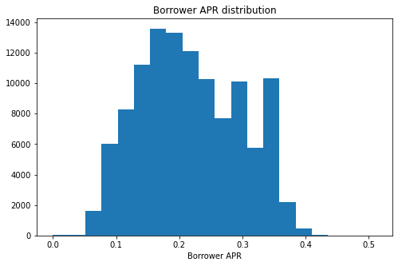

```python
binsize = df['APR'].max()/20
bins = np.arange(0, df['APR'].max()+binsize, binsize)

plt.figure(figsize=[8, 5])
plt.hist(data = df, x = 'APR', bins = bins)
plt.xlabel('Borrower APR')
plt.title('Borrower APR distribution')
plt.show()
```

## Borrower APR's vs amount of loan

> As expected the higher the loan's amount the lower the APR which is to encourage investors

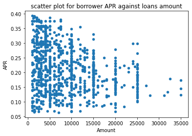

```python
df.sample(1000).plot(x='Amount',y='APR',kind='scatter',title='scatter plot for borrower APR against loans amount');
```

> A36 months term is the most common loan

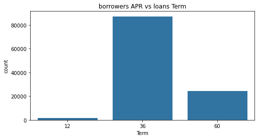

```python
fig, ax = plt.subplots(nrows=1, figsize = [8,4])
default_color = sb.color_palette()[0]
sb.countplot(data = df, x = 'Term', color = default_color)
plt.title('borrowers APR vs loans Term')
plt.show()
```

## Borrower APR vs loan's term taking the amount of the loan in regard

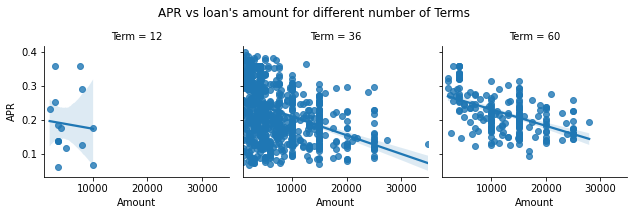

```python
# create faceted heat maps on levels of the Term variable
g=sb.FacetGrid(data=df.sample(1000), col='Term')
g.map(sb.regplot, 'Amount', 'APR');
plt.subplots_adjust(top=0.8)
g.fig.suptitle("APR vs loan's amount for different number of Terms")
plt.show();
```

## Borrower APR vs number of current loans for the client taking the amount of the loan in regard

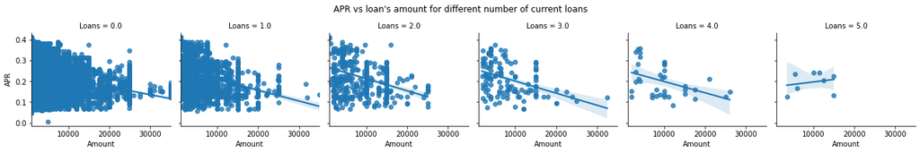

```python
# create faceted heat maps on levels of the Loans variable
g=sb.FacetGrid(data=df.sample(10000), col='Loans')
g.map(sb.regplot, 'Amount', 'APR');
plt.subplots_adjust(top=0.8)
g.fig.suptitle("APR vs loan's amount for different number of current loans")
plt.show();
```